# projet 2 série temporelle

TETE Kokou

2025-04-10

```r
# Chargement des packages
library(forecast)
library(TSA)
```

## Exercice 1

Dans ce projet, on simule une série temporelle suivant le processus :
$$x_t−0.3x_{t−1}−0.4x_{t−2}=ε_t$$

où $ε_t∼N(0,4)$ est un bruit blanc.

Nous allons :

ajuster un modèle MA(1) pour montrer qu’il est inadéquat,

ajuster ensuite le bon modèle AR(2),

comparer les ACF et PACF empiriques et théoriques.

#### 1.

On essaye d’ajuster un modèle MA(1) et on montre grâce à un test de blancheur des résidus, que ce modèle ne convient pas.

```r
# Simulation du processus donne (AR2)

pol <- c(1, -0.3, -0.4)
x <- arima.sim(n = 500, list(ar = -pol[-1]), sd = sqrt(4))
```

Visualisons la serie

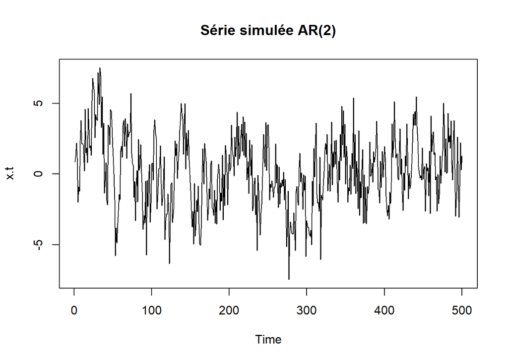

```r
plot(x, main = "Série simulée AR(2)", ylab = "x.t")
```

Vérifions la stationnarité de la série en détèrminant le module des racines du polynome de la partie autoregressive du processus

```r
roots <- polyroot(pol) #
Mod(roots)
```

```
## [1] 1.25 2.00
```

les racines ont un module strictement superieur a 1 donc on peut belle et bien affirmer la stationnarite de la série

#### Estimation du polynome P et Q pour le modele MA(1)

```r
mod=arima(x,order=c(0,0,1))
mod
```

```
##
## Call:
## arima(x = x, order = c(0, 0, 1))
##
## Coefficients:
##          ma1  intercept
##       0.3666     0.1904
## s.e.  0.0317     0.1385
##
## sigma^2 estimated as 5.139:  log likelihood = -1118.73,  aic = 2241.47
```

```r
summary(mod)
```

```
##
## Call:
## arima(x = x, order = c(0, 0, 1))
##
## Coefficients:
##          ma1  intercept
##       0.3666     0.1904
## s.e.  0.0317     0.1385
##
## sigma^2 estimated as 5.139:  log likelihood = -1118.73,  aic = 2241.47
##
## Training set error measures:
##                       ME     RMSE      MAE      MPE     MAPE      MASE
## Training set 8.27851e-05 2.266837 1.817611 65.01056 196.1159 0.9646696
##                   ACF1
## Training set 0.1676587
```

Ici l’estimation nous donne un polynome Q d’un coéfficient au temps t-1, d’une moyenne empirique et d’une variance empirique dont on ne peut pas mettre les valeurs en commentaire, car elles changes a chaque Run.

#### Analyse des résidus

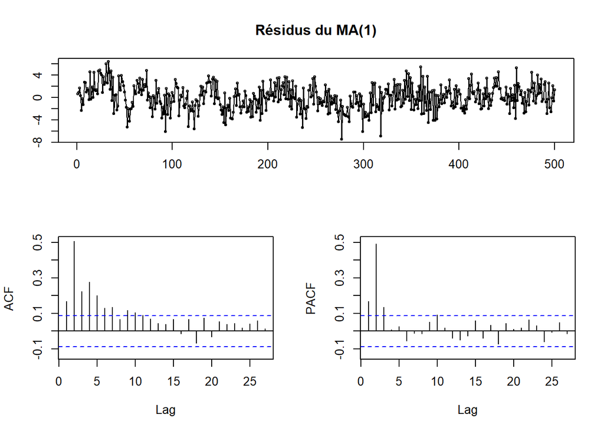

```r
tsdisplay(residuals(mod), main = "Résidus du MA(1)")
```

Les autocorrelations sortent de la bande donc le modèle ne capte pas la structure

Faisons un test pour vérifier si les residus sont du bruit blanc ou pas sous les hypotheses

H0 :“les résidus ne sont pas autocorrélés (→ c’est du bruit blanc)” contre H1 :“les résidus sont autocorrélés (→ modèle mal ajusté)” au niveau de risque 5%

```r
Box.test(residuals(mod),type = "Ljung-Box")
```

```
##
##  Box-Ljung test
##
## data:  residuals(mod)
## X-squared = 14.139, df = 1, p-value = 0.0001698
```

p-value est inférieure a apha=0.05 donc on rejètte l’hypothèse H0 et on affirme que les résidus ne sont pas du bruit blanc

#### 2.

Le modèle adéquat ici est un AR(2), on peut confirmer cela en visualisant sont ACF et sont PACF et lire le coéfficient sur la sortie de PACF

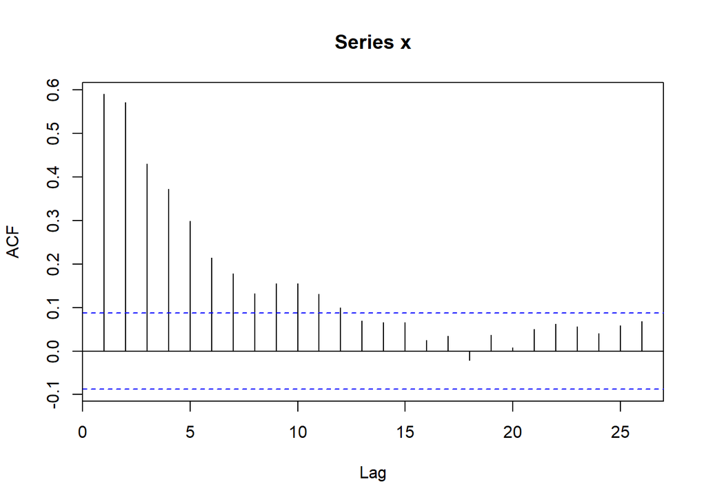

```r
acf(x)
```

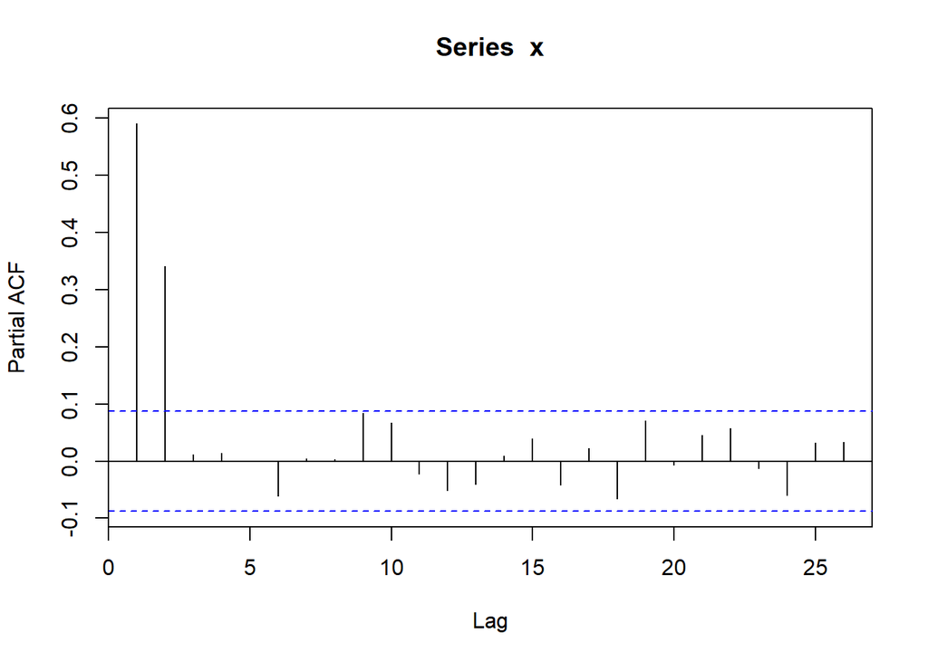

```r
pacf(x)
```

Analysons les résidus du modèle choisi AR(2)

```r
mod=arima(x,order=c(2,0,0))
summary(mod)
```

```
##
## Call:
## arima(x = x, order = c(2, 0, 0))
##
## Coefficients:
##          ar1     ar2  intercept
##       0.3881  0.3405     0.1998
## s.e.  0.0419  0.0419     0.3152
##
## sigma^2 estimated as 3.717:  log likelihood = -1038.02,  aic = 2082.04
##
## Training set error measures:
##                        ME     RMSE      MAE      MPE     MAPE      MASE
## Training set -0.001751764 1.927897 1.533963 12.87638 257.9953 0.8141275
##                      ACF1
## Training set -0.003316291
```

Ici l’estimation nous donne un polynome P de coéfficient au temps t-1 et au temps t-2, de moyenne empirique et de variance empirique dont on ne peut pas mettre les valeurs en commentaire, car elles changes a chaque Run.

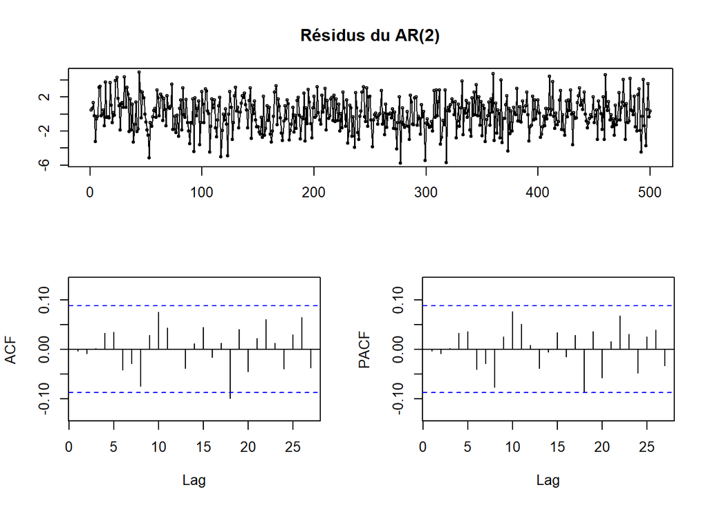

```r
tsdisplay(residuals(mod), main = "Résidus du AR(2)")
```

Passons maintenant au test de blancheur des résidus pour confirmer l’affirmation ci-dessus

```r
Box.test(residuals(mod),type = "Ljung-Box")
```

```
##
##  Box-Ljung test
##
## data:  residuals(mod)
## X-squared = 0.005532, df = 1, p-value = 0.9407
```

Ici la p-value est supérieure à alpha=0.05 donc on ne rejette pas HO et donc on affirme que les résidus sont du bruit blanc .

#### 3.

Comparaisons de l’ACF et PAC théorique et empirique

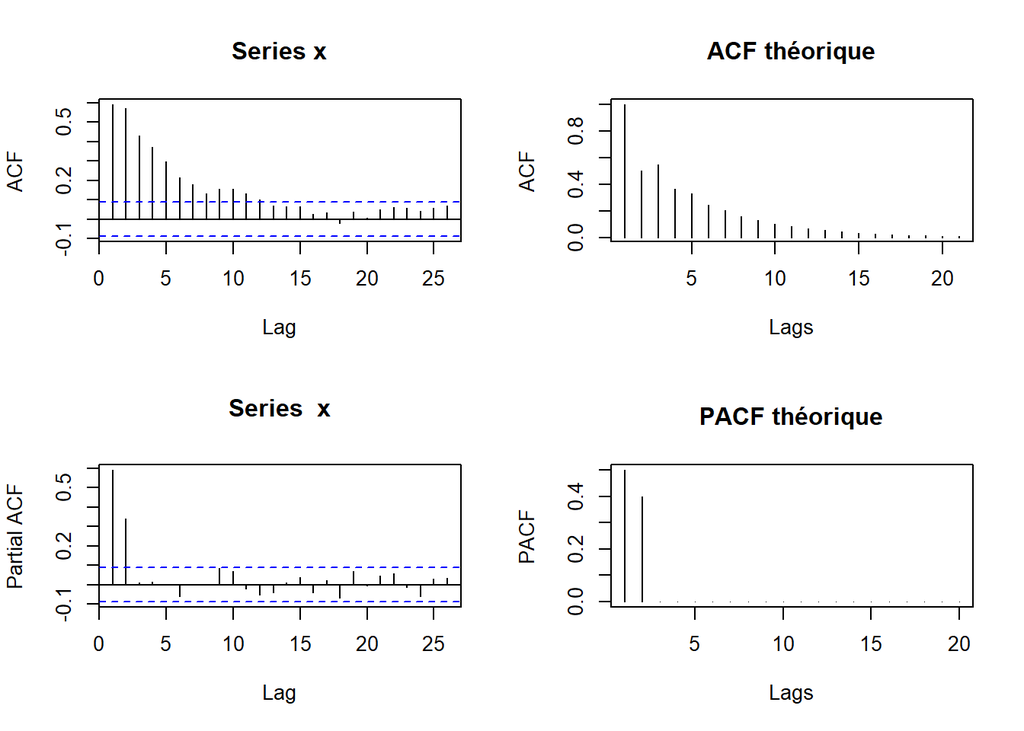

```r
par(mfrow=c(2,2))

# Les theoriques
acf_theo <- ARMAacf(ar=c(0.3,0.4), , lag.max = 20)
pacf_theo <- ARMAacf(ar=c(0.3,0.4), lag.max = 20, pacf = TRUE)

# Les observes
acf(x)
plot(acf_theo, type = "h", main = "ACF théorique", xlab = "Lags", ylab = "ACF")
pacf(x)
plot(pacf_theo,type = "h", main = "PACF théorique", xlab = "Lags", ylab = "PACF")
```

On remarque que les ACF et PACF empirique et théorique sont presque identique donc ça capte bien le modèle

## Exercice 2

Refaisons la même chose que l’exercice 1 avec le processus suivant
$$x_t=ε_t+0.5ε_{t−1}−0.4ε_{t−2}+0.3ε_{t−3}$$

Nous allons :

ajuster un modèle MA(1) pour montrer qu’il est inadéquat, ajuster ensuite le bon modèle MA(3), comparer les ACF et PACF empiriques et théoriques.

#### 1.

On essaye d’ajuster un modèle MA(1) et on montre grâce à un test de blancheur des résidus, que ce modèle ne convient pas.

```r
# Simulation du processus donne (AR2)

pol <- c(1, 0.5,-0.4,0.3 )
x <- arima.sim(n = 500, list(ma = pol), sd = sqrt(4))
```

Visualisons la série

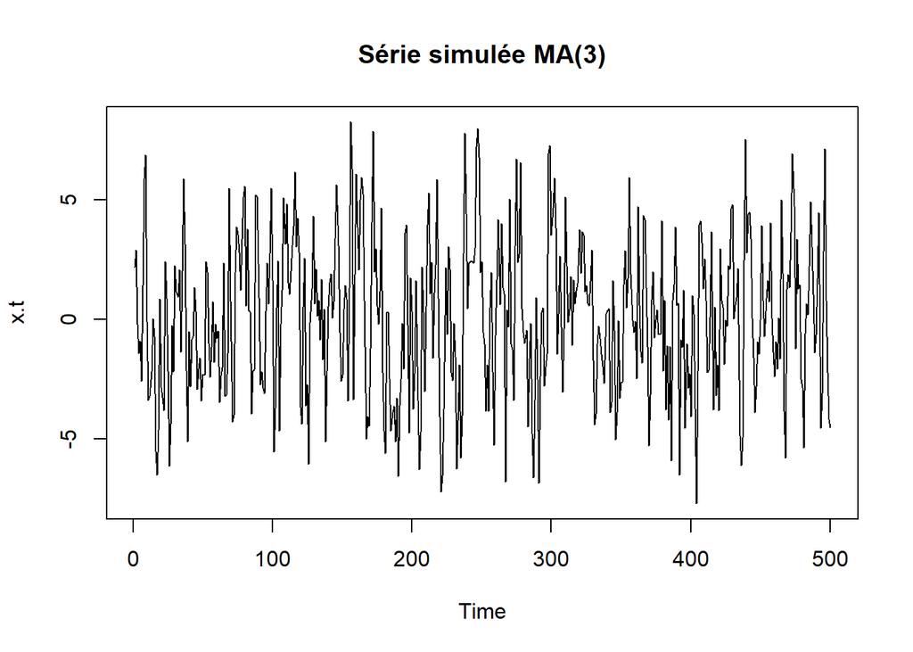

```r
plot(x, main = "Série simulée MA(3)", ylab = "x.t")
```

Tout processus moyenne mobile est stationnaire donc on peut avancer sans aucun probleme

#### Estimation du polynome P et Q pour le modele MA(1)

```r
mod=arima(x,order=c(0,0,1))

summary(mod)
```

```
##
## Call:
## arima(x = x, order = c(0, 0, 1))
##
## Coefficients:
##          ma1  intercept
##       0.4269     0.0691
## s.e.  0.0301     0.1808
##
## sigma^2 estimated as 8.041:  log likelihood = -1230.72,  aic = 2465.43
##
## Training set error measures:
##                        ME     RMSE      MAE      MPE     MAPE      MASE
## Training set -0.001288019 2.835709 2.310508 45.28906 163.7044 0.8807742
##                  ACF1
## Training set 0.116057
```

Ici l’estimation nous donne un polynome Q d’un coefficient au temps t-1, d’une moyenne empirique et d’une variance empirique dont on ne peut pas mettre les valeurs en commentaire, car elles changes a chaque Run.

## Analyse des residus

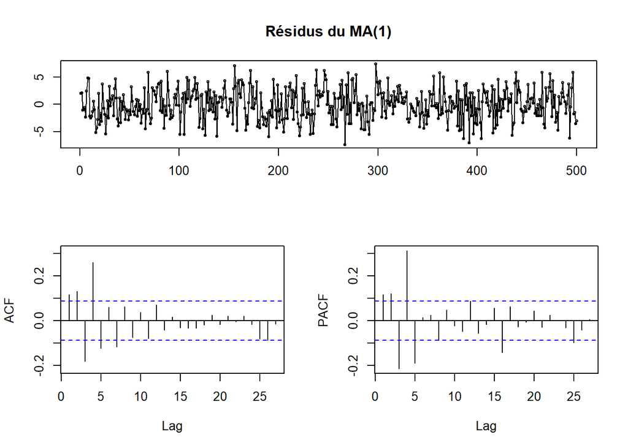

```r
tsdisplay(residuals(mod), main = "Résidus du MA(1)")
```

Les autocorrelations sortent de la bande donc le modèle ne capte pas la structure

Faisons un test pour vérifier si les résidus sont du bruit blanc ou pas sous les hypothèses H0 :“les résidus ne sont pas autocorrélés (→ c’est du bruit blanc)” contre H1 :“(alternative) : les résidus sont autocorrélés (→ modèle mal ajusté”) au niveau de risque 5%

```r
Box.test(residuals(mod),type = "Ljung-Box")
```

```
##
##  Box-Ljung test
##
## data:  residuals(mod)
## X-squared = 6.7751, df = 1, p-value = 0.009244
```

#### 2.

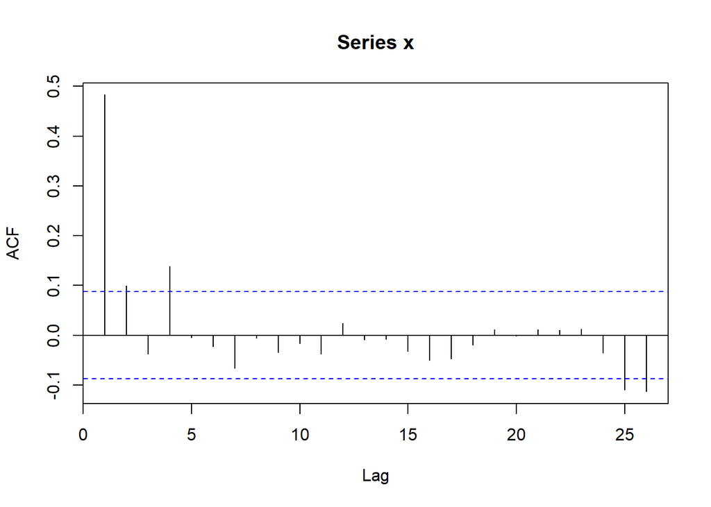

```r
acf(x)
```

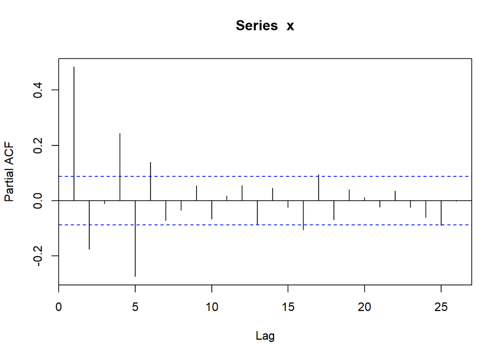

```r
pacf(x)
```

Analysons les résidus du modèle choisi : MA(3)

```r
mod=arima(x,order=c(0,0,3))
summary(mod)
```

```
##
## Call:
## arima(x = x, order = c(0, 0, 3))
##
## Coefficients:
##          ma1     ma2      ma3  intercept
##       0.7615  0.2086  -0.3281     0.0669
## s.e.  0.0407  0.0460   0.0406     0.1877
##
## sigma^2 estimated as 6.539:  log likelihood = -1179.62,  aic = 2367.25
##
## Training set error measures:
##                        ME     RMSE     MAE       MPE     MAPE      MASE
## Training set 0.0004955013 2.557115 2.06943 -4.741108 230.8179 0.7888744
##                     ACF1
## Training set -0.05770361
```

Ici l’estimation nous donne un polynome Q de coéfficient au temps t-1, au temps t-2 et au t-3 de moyenne empirique et de variance empirique dont on ne peut pas mettre les valeurs en commentaire, car elles changes a chaque Run.

Analyse des residus

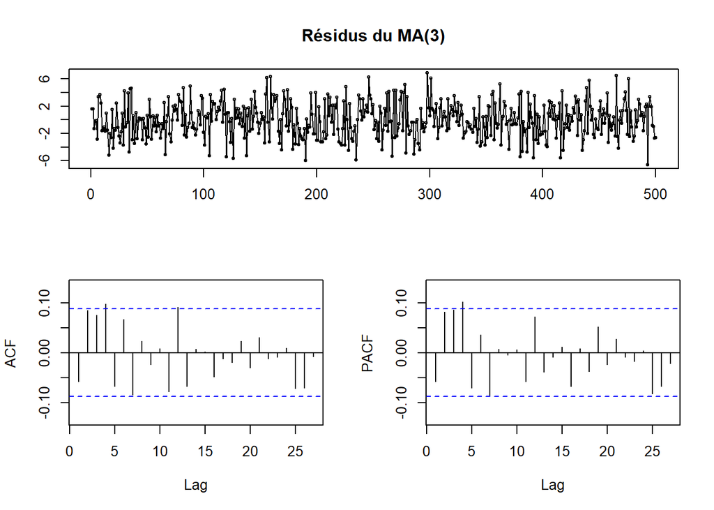

```r
tsdisplay(residuals(mod), main = "Résidus du MA(3)")
```

Passons maintenant au test de blancheur des résidus pour confirmer l’affirmation ci dessus

```r
Box.test(residuals(mod),type = "Ljung-Box")
```

```
##
##  Box-Ljung test
##
## data:  residuals(mod)
## X-squared = 1.6749, df = 1, p-value = 0.1956
```

Ici la p-value est supérieure a alpha=0.05 donc on ne rejette pas HO et donc on affirme que les residus sont du bruit blanc

#### 3.

Comparaisons de l’ACF et PAC theorique et empirique

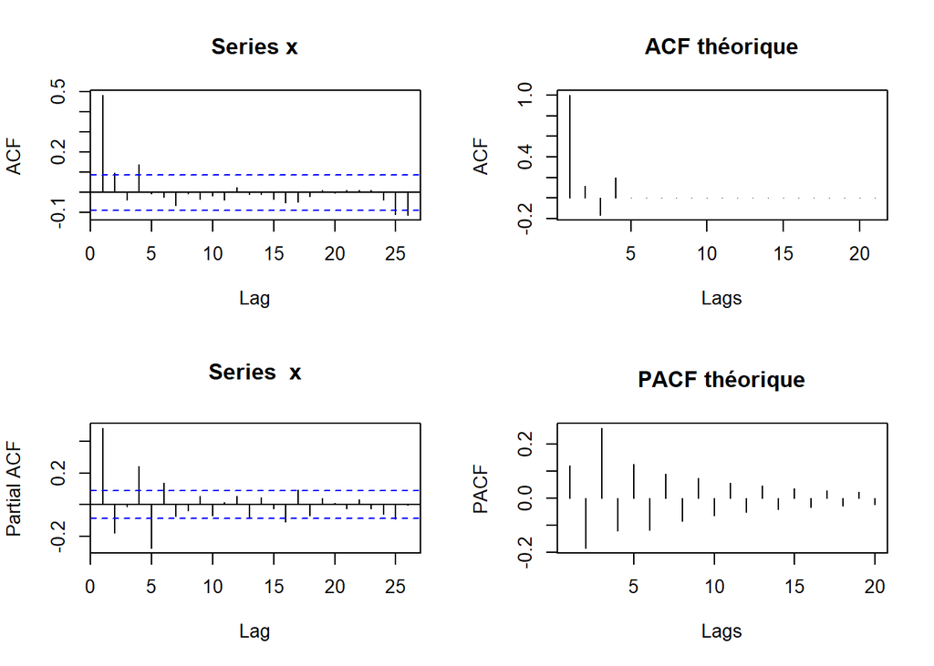

```r
par(mfrow=c(2,2))

# Les theoriques
acf_theo <- ARMAacf(ma=c(0.5,-0.4,0.3), lag.max = 20)
pacf_theo <- ARMAacf(ma=c(0.5,-0.4,0.3), lag.max = 20, pacf = TRUE)

# Les observes
acf(x)
plot(acf_theo, type = "h", main = "ACF théorique", xlab = "Lags", ylab = "ACF")
pacf(x)
plot(pacf_theo,type = "h", main = "PACF théorique", xlab = "Lags", ylab = "PACF")
```

## Exercice 3

Chargement du jeux de données

```r
load("C:/serie_temporelle/projet/projet 2-20250408/co2.RData")
head(tco2)
```

```
## Time Series:
## Start = 2017.05212620027
## End = 2017.0658436214
## Frequency = 364.5
## [1] 0.9679286 1.0173291 1.2854802 1.3501522 1.6041617 2.0095152
```

```r
summary(tco2)
```

```
##     Min.  1st Qu.   Median     Mean  3rd Qu.     Max.
## -14.6950  -3.3596  -0.1121  -1.1882   1.0778  11.3887
```

Affichage de la série

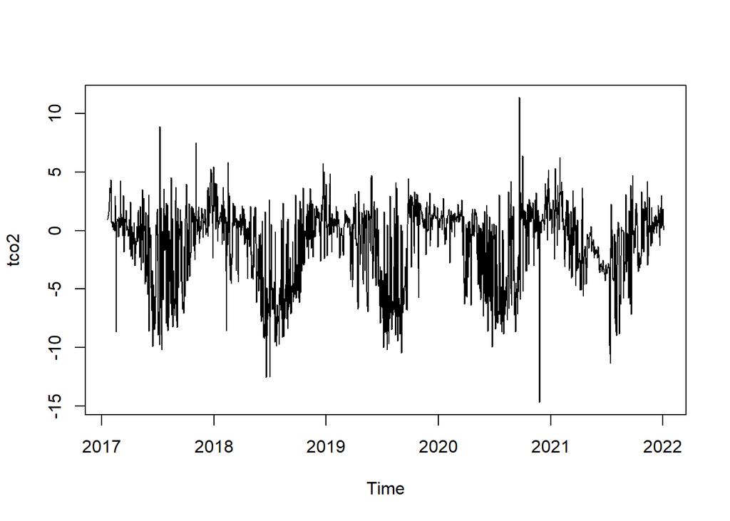

```r
plot(tco2)
```

Vérifions la stationnarité de la série en visualisant son ACF et ensuite faire un test.

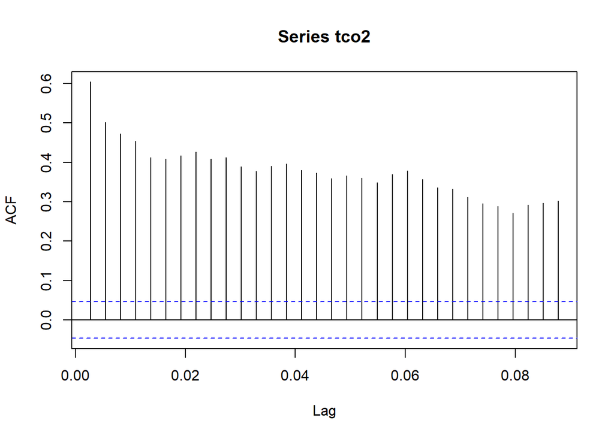

```r
acf(tco2)
```

La décroissance est lente, on peut affirmer le présence d’une tendance.

Passons au test de Dickey-Fuller pour verifier la stionnarité sous les hypothèses suivantes :

```
 H0 : il y a une racine unitaire (donc série non stationnaire)
 H1 : la série est stationnaire
```

```r
 library(tseries)
adf.test(tco2)
```

```
##
##  Augmented Dickey-Fuller Test
##
## data:  tco2
## Dickey-Fuller = -5.008, Lag order = 12, p-value = 0.01
## alternative hypothesis: stationary
```

la p-value est inférieure à 0.05 donc on rejette H0, et on peut conclure que la série est stationnaire

La fonction xreg dans auto.arima() (du package forecast) permet d’ajouter des régressseurs externes au modèle ARIMA, autrement dit, c’est pour ajuster un modèle ARIMAX

créons des variables saisonnières périodiques sur base d’un cycle de 365 jours et faisons en une regression avec, pour obtenir quelque chose de la sorte :

```r
# Harmoniques saisonnières

season<-harmonic(tco2,m=1)
mod <- auto.arima(tco2, xreg = season)
summary(mod)
```

```
## Series: tco2
## Regression with ARIMA(2,0,1) errors
##
## Coefficients:
##          ar1      ar2      ma1  intercept  cos(2*pi*t)  sin(2*pi*t)
##       1.1918  -0.2405  -0.8528    -1.1646       2.7054       0.5313
## s.e.  0.0504   0.0353   0.0419     0.1723       0.2376       0.2378
##
## sigma^2 = 5.96:  log likelihood = -4174.01
## AIC=8362.01   AICc=8362.07   BIC=8400.51
##
## Training set error measures:
##                         ME     RMSE      MAE      MPE     MAPE      MASE
## Training set -0.0009008236 2.437293 1.751137 350.0507 614.1647 0.6460695
##                      ACF1
## Training set -0.003033087
```

l’estimation nous donne un ARIMA(2,1)

Diagnostic du modèle en étudiant ses residus

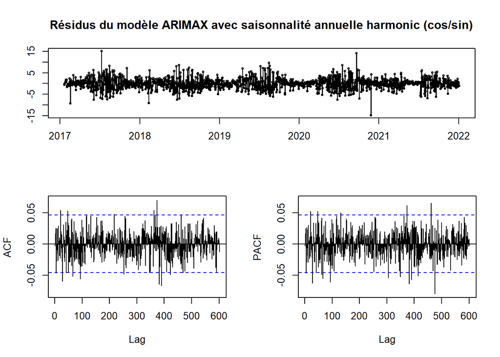

```r
tsdisplay(residuals(mod), main = "Résidus du modèle ARIMAX avec saisonnalité annuelle harmonic (cos/sin)")
```

```r
Box.test(residuals(mod), lag = 30, type = "Ljung-Box")
```

```
##
##  Box-Ljung test
##
## data:  residuals(mod)
## X-squared = 32.236, df = 30, p-value = 0.3566
```

les autocorrelations ne nous permettent pas d’affirmer clairement que les résidus sont du bruit blanc à cause du faite que certains sont légèrement sortie de la bande .

Mais en ce qui concerne le test de blancheur, la p-valeur est supérieure à alpha(0.05), donc on ne rejette pas HO (les résidus sont du bruit blancs) et donc on peut affirmer que résidus sont du bruit blanc

Dans la partie précédante, on a applique l’harmonic à la série entière

Mais ici, c’est à partir du debut jusqu’a 1a fin de 2019 qui nous interèsse pour prédire 2020, pour cela on a aussi besoin d’une saisonalite harmonic pour la durée à prédire

```r
train <- window(tco2, end = c(2019, 365))
harm_train <- harmonic(train, m = 1) #Creation de l'harmonic pour la periode train

# Creation de l'harmonic pour le futur
length_pred <- 365  # 1 an de prédiction (2020)
harm_pred <- harmonic(ts(rep(NA, length_pred), frequency = 365, start = c(2020, 1)), m = 1)

# Ajustons l'harmonic d'apprentissage sur l’échantillon d’apprentissage

mod <- auto.arima(train, xreg = harm_train)
summary(mod)
```

```
## Series: train
## Regression with ARIMA(2,0,2) errors
##
## Coefficients:
##          ar1      ar2      ma1     ma2  intercept  cos(2*pi*t)  sin(2*pi*t)
##       1.4226  -0.4459  -1.1070  0.1886    -1.2725       2.8395       0.8037
## s.e.  0.1389   0.1293   0.1473  0.1176     0.2653       0.3540       0.3562
##
## sigma^2 = 6.381:  log likelihood = -2518.16
## AIC=5052.33   AICc=5052.46   BIC=5092.17
##
## Training set error measures:
##                        ME     RMSE      MAE      MPE    MAPE      MASE
## Training set 0.0003574335 2.517783 1.834711 4.627534 282.496 0.6470969
##                     ACF1
## Training set 0.001563708
```

l’estimation nous donne un ARIMA(2,2)

Diagnostic du modèle en étudiant ses résidus

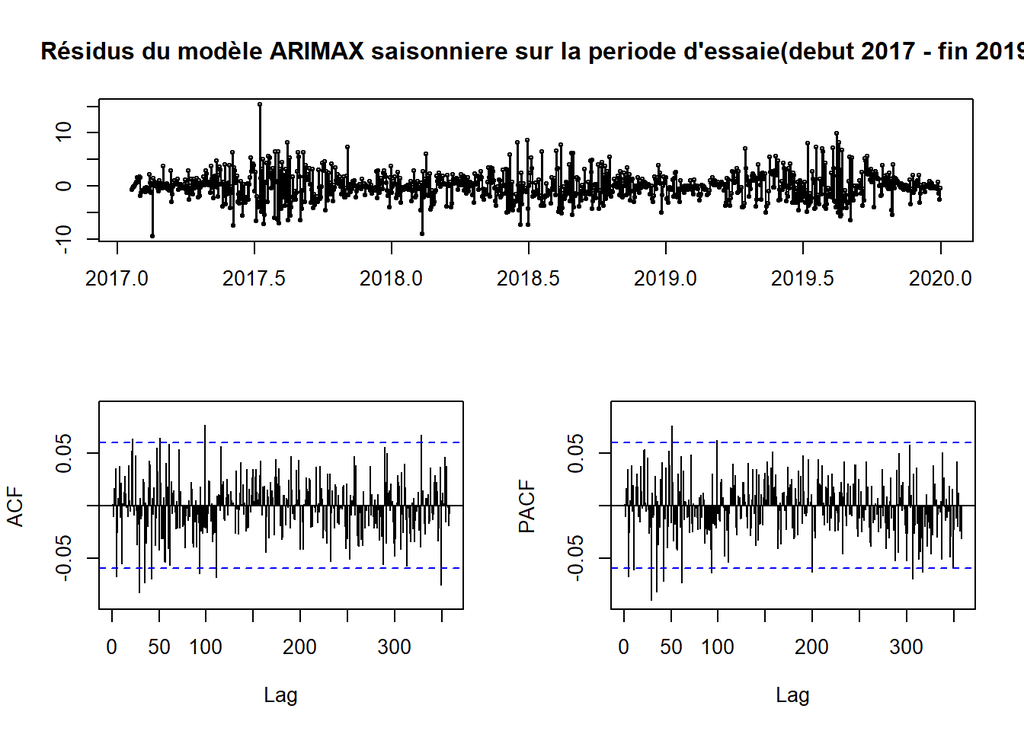

```r
tsdisplay(residuals(mod), main = "Résidus du modèle ARIMAX saisonniere sur la periode d'essaie(debut 2017 - fin 2019")
```

les autocorrelations ne nous permettent pas d’affirmer clairement que les résidus sont du bruit blanc à cause du faite que certains sont legèrement sortie de la bande .

```r
Box.test(residuals(mod), lag = 30, type = "Ljung-Box")
```

```
##
##  Box-Ljung test
##
## data:  residuals(mod)
## X-squared = 35.374, df = 30, p-value = 0.2293
```

Mais en ce qui concerne le test de blancheur, la p-valeur est supérieure à alpha(0.05), donc on ne rejette pas HO (les résidus sont du bruit blancs) et donc on peut valider le modèle

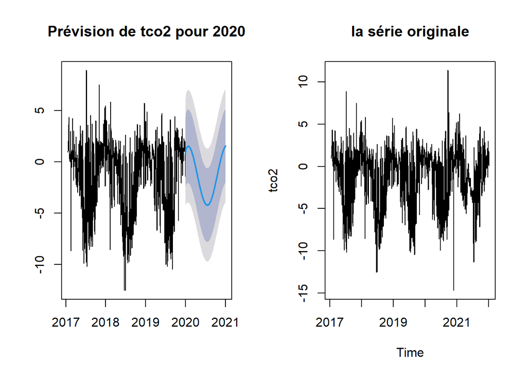

```r
# Prédire jusqu’à fin 2020
par(mfrow=c(1,2))

pred <- forecast(mod, h = length_pred, xreg = harm_pred)
plot(pred, main = "Prévision de tco2 pour 2020")
plot(tco2,main="la série originale" )
```

```r
#summary(pred)  je l'ai mi en commentaire parce qu'à la sortie, ça me présente aussi le tableau des données de la prévision, ce qui encombre .
```

```r
min(tco2); max(tco2)
```

```
## [1] -14.695
```

```
## [1] 11.3887
```